# Re-analysis of Feit et al. (2016)

### Install the following packages. Ensure R version >= 4.00.

```r
#Install the following packages. Ensure R version >= 4.00.
install.packages("tidyverse")
install.packages("ggplot2")
install.packages("readxl")
install.packages("openxlsx")
install.packages("Hmisc")
install.packages("modelr")
install.packages("qqplotr")
install.packages("dplyr")
install.packages("ggbeeswarm")
install.packages("broom")
install.packages("car")
```

## Separate text files into different conditions and extract data from questionnaire

- Parse the file names to differentiate between mixed, sentence and random conditions.

*OUTPUT:* Mixed: list of file names that contain the mixed condition. Sentence: list of file names that contain the sentence condition. Random: list of file names that contain the random condition.

- Assign touch typist and non-touch-typist according to the answer in the questionnaire.

*OUTPUT:* touch_typist_id: a list of user_id strings that are from touch typists. non_touch_typist_id: a list of user_id strings that are from non-touch typists.

```r
#data_file_paths <- list.files("data", full.names = TRUE)
mixed =list.files("data",pattern="[^(a-zA-Z)]*(Mix)[^(a-zA-Z)]*", full.names = TRUE)
random =list.files("data",pattern="[^(a-zA-Z)]*(Random)[^(a-zA-Z)]*", full.names = TRUE)
sentence =list.files("data",pattern="[^(a-zA-Z)]*(Sentence)[^(a-zA-Z)]*", full.names = TRUE)

# 2 x 1 touch typist
read_xls <- read.xlsx("Background.xlsx")


touch_typist <- which(read_xls$`Do.you.use.the.touch.typing.system.with.all.10.fingers?.If.so,.how.many.years.of.experience.do.you.have?`>= 1)
non_touch_typist <- which(read_xls$`Do.you.use.the.touch.typing.system.with.all.10.fingers?.If.so,.how.many.years.of.experience.do.you.have?`< 1)

touch_typist_id <- read_xls[c(touch_typist),1]
non_touch_typist_id <- read_xls[c(non_touch_typist),1]



#non_touch_typist <- which(read_xls[13] <= 1)
#n <- subset(read_xls, select = c(touch_typist) )
```

# Extract data:

OUTPUT: 3 dataframes for the 3 conditions: mixed_mod random_mod sentence_mod All containing

input_time user_id stimulus_id input_index iki input key_symbol current_input wpm sd_iki stimulus condition input_time_ms uer ke

```r
i = 0
vars <- c("mixed", "random", "sentence")
for (var in vars){
  i = 0
  for (path in eval(parse(text=var))){
    if (i == 0){
    nam <- paste(var, "mod", sep="_")
    tabcurr <- read.table(file=path, sep="\t", quote="", comment.char="")
    colnames(tabcurr) <- lapply(tabcurr[1, ], as.character)
    tabcurr <- tabcurr[-1,]
    assign(nam, tabcurr)

    }
    else{
    newtab <- read.table(file=path, sep="\t", quote="", comment.char="")
    colnames(newtab) <- lapply(newtab[1, ], as.character)
    newtab <- newtab[-1,]
    chars <- as.character("mixed_mod")

   if (nam[[1]] == as.character("mixed_mod")){
     mixed_mod <- rbind(newtab, mixed_mod)
   } else if (nam[[1]] == as.character("random_mod")){
     random_mod <- rbind(newtab, random_mod)
   } else if (nam[[1]] == as.character("sentence_mod")){
     sentence_mod <- rbind(newtab, sentence_mod)
   }

  }
  i <- i + 1
  }
  }
```

# Creating a Dataset with the needed attributes for comparison:

*OUTPUT* Dataframes with the following names:

NonTouchTypist_mixed_mode NonTouchTypist_sentence_mode NonTouchTypist_random_mode

TouchTypist_mixed_mode TouchTypist_sentence_mode TouchTypist_random_mode

Including: user_id, mean_wmp_per_person, mean_sd_iki_per_person, mean_uer_per_person, mean_ke_per_person

```r
sentence_mod <- as.data.frame.matrix(sentence_mod)
mixed_mod <- as.data.frame.matrix(mixed_mod)
random_mod <- as.data.frame.matrix(random_mod)
condition_list <- list(sentence_mod, mixed_mod, random_mod)
names_of_dataframes <- list("sentence_mod", "mixed_mod", "random_mod")
i = 1
for (df in condition_list){
  wmp_nam <- paste(names_of_dataframes[i] , "wmp", sep="_")
  sd_iki_nam <- paste(names_of_dataframes[i] , "sd_iki", sep="_")
  uer_nam <- paste(names_of_dataframes[i] , "uer", sep="_")
    ke_nam <- paste(names_of_dataframes[i] , "ke", sep="_")

  #Create one sd_iki per input per person
  assign(sd_iki_nam, df %>% group_by(user_id, current_input) %>% summarise(mean_iki = mean(as.numeric(sd_iki)))%>% group_by(user_id) %>% summarise(mean_sd_iki= mean(as.numeric(mean_iki))))

#Create one wmp per input per person
  assign(wmp_nam, df %>% group_by(user_id, current_input) %>% summarise(m_wmp = mean(as.numeric(wpm)))%>% group_by(user_id) %>% summarise(mean_wmp= mean(as.numeric(m_wmp))))

  #Create one uer per input per person
  assign(uer_nam, df %>% group_by(user_id, current_input) %>% summarise(m_uer = mean(as.numeric(uer)))%>% group_by(user_id) %>% summarise(mean_uer= mean(as.numeric(m_uer))))

    #Create one ke per input per person
  assign(ke_nam, df %>% group_by(user_id, current_input) %>% summarise(m_ke = mean(as.numeric(ke)))%>% group_by(user_id) %>% summarise(mean_ke= mean(as.numeric(m_ke))))

#Mean wmp per person
  print(df)
currnam_wmp <-  df %>% group_by(user_id, current_input) %>% summarise(m = mean(as.numeric(wpm)))%>% group_by(user_id) %>% summarise(mean_wmp_per_person = mean(as.numeric(m)))

#Mean sd_iki per person  to use var below
currnam_sd_iki <-  df %>% group_by(user_id, current_input) %>% summarise(m = mean(as.numeric(sd_iki)))%>% group_by(user_id) %>% summarise(mean_sd_iki_per_person = mean(as.numeric(m)))

#Mean uer per person to use var below
currnam_uer <-  df %>% group_by(user_id, current_input) %>% summarise(m = mean(as.numeric(uer)))%>% group_by(user_id) %>% summarise(mean_uer_per_person = mean(as.numeric(m)))

#Mean ke per person to use var below
currnam_ke <-  df %>% group_by(user_id, current_input) %>% summarise(m = mean(as.numeric(ke)))%>% group_by(user_id) %>% summarise(mean_ke_per_person = mean(as.numeric(m)))

#Separate data set in Touch typist and nontouch typist
tt <- paste("TouchTypist" , names_of_dataframes[i], sep="_")
ntt <- paste("NonTouchTypist" , names_of_dataframes[i], sep="_")

#Assign parts of dataset containing the mean wmp to either touch-typist or non-touch typist
tt_wmp <- currnam_wmp[currnam_wmp$user_id %in% c(touch_typist_id),]
ttsd_iki <- currnam_sd_iki[currnam_sd_iki$user_id %in% c(touch_typist_id),]
tt_uer <-currnam_uer[currnam_uer$user_id %in% c(touch_typist_id),]
tt_ke <-currnam_ke[currnam_ke$user_id %in% c(touch_typist_id),]
ttlist <- list(tt_wmp, ttsd_iki, tt_uer, tt_ke)

#can be extended for the additional attributes
assign(tt, Reduce(
  function(x, y, ...) merge(x, y, ...),
  ttlist
))

#Assign parts of dataset containing the mean of the different measures to either touch-typist or non-touch typist
ntt_wmp <- currnam_wmp[currnam_wmp$user_id %in% c(non_touch_typist_id),]
nttsd_iki <- currnam_sd_iki[currnam_sd_iki$user_id %in% c(non_touch_typist_id),]
ntt_uer <-currnam_uer[currnam_uer$user_id %in% c(non_touch_typist_id),]
ntt_ke <-currnam_ke[currnam_ke$user_id %in% c(non_touch_typist_id),]

nttlist <- list(ntt_wmp, nttsd_iki, ntt_uer, ntt_ke)

assign(ntt, Reduce(
    function(x, y, ...) merge(x, y, ...),
    nttlist
  ))
  i <- i + 1

}
```

|  | input_time | user_id | stimulus_id | input_index | iki | input | key_symbol | current_input | wpm | sd_iki | stimulus | condition | input_time_ms | uer | ke |
| --- | --- | --- | --- | --- | --- | --- | --- | --- | --- | --- | --- | --- | --- | --- | --- |
| 2 | 1437729588.79 | 96115 | 0 | 0 | 0 | Shift_L | Shift_L | Ei ollut edes lähellä. | 55.72 | 123.93 | Ei ollut edes lähellä. | Sentences | 0 | 0 | 0.96 |
| 3 | 1437729589.227 | 96115 | 0 | 1 | 437 | E | E | Ei ollut edes lähellä. | 55.72 | 123.93 | Ei ollut edes lähellä. | Sentences | 437 | 0 | 0.96 |
| 4 | 1437729589.414 | 96115 | 0 | 2 | 187 | i | i | Ei ollut edes lähellä. | 55.72 | 123.93 | Ei ollut edes lähellä. | Sentences | 624 | 0 | 0.96 |
| 5 | 1437729589.507 | 96115 | 0 | 3 | 93 | _ | space | Ei ollut edes lähellä. | 55.72 | 123.93 | Ei ollut edes lähellä. | Sentences | 717 | 0 | 0.96 |
| 6 | 1437729589.757 | 96115 | 0 | 4 | 250 | o | o | Ei ollut edes lähellä. | 55.72 | 123.93 | Ei ollut edes lähellä. | Sentences | 967 | 0 | 0.96 |
| 7 | 1437729589.944 | 96115 | 0 | 5 | 187 | l | l | Ei ollut edes lähellä. | 55.72 | 123.93 | Ei ollut edes lähellä. | Sentences | 1154 | 0 | 0.96 |
| 8 | 1437729590.1 | 96115 | 0 | 6 | 155 | l | l | Ei ollut edes lähellä. | 55.72 | 123.93 | Ei ollut edes lähellä. | Sentences | 1309 | 0 | 0.96 |
| 9 | 1437729590.381 | 96115 | 0 | 7 | 282 | u | u | Ei ollut edes lähellä. | 55.72 | 123.93 | Ei ollut edes lähellä. | Sentences | 1591 | 0 | 0.96 |
| 10 | 1437729590.475 | 96115 | 0 | 8 | 93 | t | t | Ei ollut edes lähellä. | 55.72 | 123.93 | Ei ollut edes lähellä. | Sentences | 1684 | 0 | 0.96 |
| 11 | 1437729590.568 | 96115 | 0 | 9 | 94 | _ | space | Ei ollut edes lähellä. | 55.72 | 123.93 | Ei ollut edes lähellä. | Sentences | 1778 | 0 | 0.96 |

[output cut: 990 more lines]

|  | input_time | user_id | stimulus_id | input_index | iki | input | key_symbol | current_input | wpm | sd_iki | stimulus | condition | input_time_ms | uer | ke |
| --- | --- | --- | --- | --- | --- | --- | --- | --- | --- | --- | --- | --- | --- | --- | --- |
| 2 | 1437730671.666 | 96115 | 0 | 0 | 0 | Shift_L | Shift_L | Mikä vtljjo tämä on? | 45.96 | 266.27 | Mikä vtljjo tämä on? | Mix | 0 | 0 | 0.91 |
| 3 | 1437730671.791 | 96115 | 0 | 1 | 125 | M | M | Mikä vtljjo tämä on? | 45.96 | 266.27 | Mikä vtljjo tämä on? | Mix | 125 | 0 | 0.91 |
| 4 | 1437730672.072 | 96115 | 0 | 2 | 281 | i | i | Mikä vtljjo tämä on? | 45.96 | 266.27 | Mikä vtljjo tämä on? | Mix | 406 | 0 | 0.91 |
| 5 | 1437730672.353 | 96115 | 0 | 3 | 281 | k | k | Mikä vtljjo tämä on? | 45.96 | 266.27 | Mikä vtljjo tämä on? | Mix | 687 | 0 | 0.91 |
| 6 | 1437730672.446 | 96115 | 0 | 4 | 93 | ä | adiaeresis | Mikä vtljjo tämä on? | 45.96 | 266.27 | Mikä vtljjo tämä on? | Mix | 780 | 0 | 0.91 |
| 7 | 1437730672.54 | 96115 | 0 | 5 | 94 | _ | space | Mikä vtljjo tämä on? | 45.96 | 266.27 | Mikä vtljjo tämä on? | Mix | 874 | 0 | 0.91 |
| 8 | 1437730672.821 | 96115 | 0 | 6 | 281 | v | v | Mikä vtljjo tämä on? | 45.96 | 266.27 | Mikä vtljjo tämä on? | Mix | 1155 | 0 | 0.91 |
| 9 | 1437730674.131 | 96115 | 0 | 7 | 1310 | t | t | Mikä vtljjo tämä on? | 45.96 | 266.27 | Mikä vtljjo tämä on? | Mix | 2465 | 0 | 0.91 |
| 10 | 1437730674.318 | 96115 | 0 | 8 | 187 | l | l | Mikä vtljjo tämä on? | 45.96 | 266.27 | Mikä vtljjo tämä on? | Mix | 2652 | 0 | 0.91 |
| 11 | 1437730674.599 | 96115 | 0 | 9 | 281 | j | j | Mikä vtljjo tämä on? | 45.96 | 266.27 | Mikä vtljjo tämä on? | Mix | 2933 | 0 | 0.91 |

[output cut: 990 more lines]

|  | input_time | user_id | stimulus_id | input_index | iki | input | key_symbol | current_input | wpm | sd_iki | stimulus | condition | input_time_ms | uer | ke |
| --- | --- | --- | --- | --- | --- | --- | --- | --- | --- | --- | --- | --- | --- | --- | --- |
| 2 | 1437730278.602 | 96115 | 0 | 0 | 0 | q | q | qslpag | 25.65 | 415.38 | qslpag | Random | 0 | 0 | 1.00 |
| 3 | 1437730279.07 | 96115 | 0 | 1 | 467 | s | s | qslpag | 25.65 | 415.38 | qslpag | Random | 467 | 0 | 1.00 |
| 4 | 1437730279.257 | 96115 | 0 | 2 | 187 | l | l | qslpag | 25.65 | 415.38 | qslpag | Random | 654 | 0 | 1.00 |
| 5 | 1437730279.538 | 96115 | 0 | 3 | 282 | p | p | qslpag | 25.65 | 415.38 | qslpag | Random | 936 | 0 | 1.00 |
| 6 | 1437730279.756 | 96115 | 0 | 4 | 218 | a | a | qslpag | 25.65 | 415.38 | qslpag | Random | 1154 | 0 | 1.00 |
| 7 | 1437730280.942 | 96115 | 0 | 5 | 1185 | g | g | qslpag | 25.65 | 415.38 | qslpag | Random | 2339 | 0 | 1.00 |
| 8 | 1437730284.436 | 96115 | 1 | 0 | 0 | u | u | uchedt | 49.30 | 111.57 | uchedt | Random | 0 | 0 | 1.00 |
| 9 | 1437730284.748 | 96115 | 1 | 1 | 311 | c | c | uchedt | 49.30 | 111.57 | uchedt | Random | 311 | 0 | 1.00 |
| 10 | 1437730284.904 | 96115 | 1 | 2 | 156 | h | h | uchedt | 49.30 | 111.57 | uchedt | Random | 467 | 0 | 1.00 |
| 11 | 1437730285.091 | 96115 | 1 | 3 | 187 | e | e | uchedt | 49.30 | 111.57 | uchedt | Random | 654 | 0 | 1.00 |

[output cut: 990 more lines]

```r
NA
```

## Merge the values obtained for plotting

OUTPUT: mixed_both sentence_both random_both

```r
#wmp = dv
#variable changed
both <- function(dfNames){
  do.call(rbind, lapply(dfNames, function(x){
    currnam <- substr(x,1, nchar(x)-16)
    cbind(get(x), source = currnam)
  }))
}
conds <- function(dfNames){
  do.call(rbind, lapply(list(dfNames), function(x){
    currnam <- substr(x,1, nchar(x)-5)
    cbind(get(x), cond = currnam)
  }))
}
mixed_both <- both(c("TouchTypist_mixed_mod", "NonTouchTypist_mixed_mod"))
sentence_both <- both(c("TouchTypist_sentence_mod", "NonTouchTypist_sentence_mod"))
random_both <- both(c("TouchTypist_random_mod", "NonTouchTypist_random_mod"))
new <- conds(c("sentence_both", "mixed_both", "random_both"))
```

# Different GLM plots

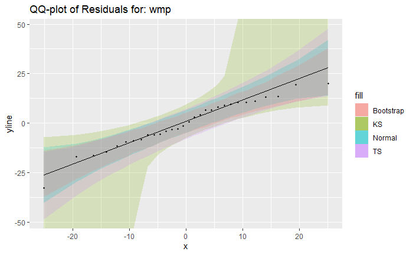

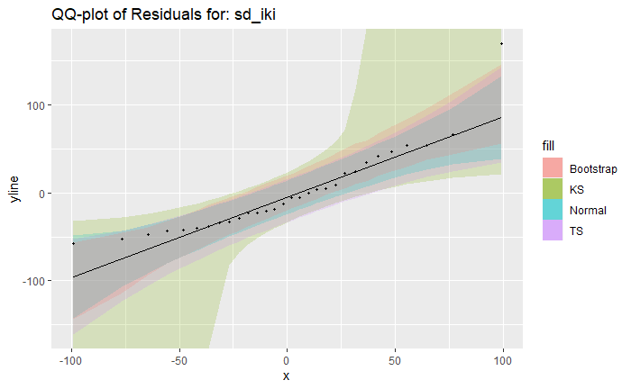

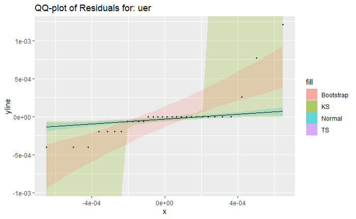

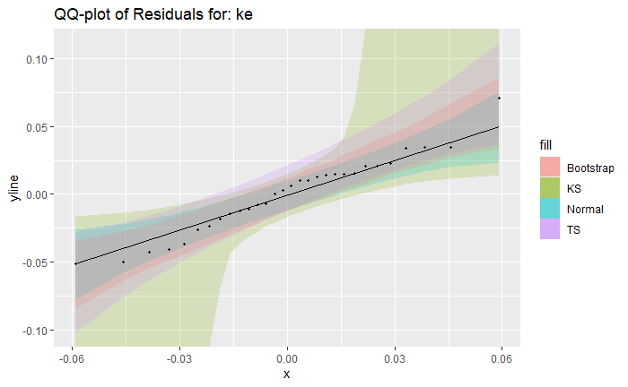

```r
m <- function(attributelist, pl){
models <- lapply(attributelist, function(x){
  curr_plot <- paste("Plot" , x, sep="_")
curr_p <- glm(substitute(i~ source*cond, list(i = as.name(x))), data= new)


curr_lm <- new %>%
  add_residuals(curr_p)

if(pl[1]== 1){
assign(curr_plot, curr_lm %>%
  ggplot(aes(sample = resid)) +
    ggtitle(str_replace_all(curr_plot, "([_])", " "))+
    geom_qq_band(bandType = "ks", mapping = aes(fill = "KS"), alpha = 0.2) +
    geom_qq_band(bandType = "ts", mapping = aes(fill = "TS"), alpha = 0.2) +
    geom_qq_band(bandType = "pointwise", mapping = aes(fill = "Normal"), alpha = 0.2)  +
        geom_qq_band(bandType = "boot", mapping = aes(fill = "Bootstrap"), alpha = 0.2) +
  stat_qq_line(size=.2) +
  stat_qq_point(size = 0.7))+
  ggtitle(paste("QQ-plot of Residuals for: ",substr(as.character(x), 6, nchar(as.character(x))-11), sep=""))

}else if(pl[1]== 2){
  summary(curr_p)
  new %>%
    group_by(source) %>%
  mutate(dist_mdn = eval(as.name(x))-mean(eval(as.name(x)))) %>%
    ggplot(aes(x=source, y =dist_mdn, group = source, colour=cond), alpha=0.9)+
    geom_violin(aes(fill=source),colour = "white", alpha = 0.2)+
    geom_beeswarm(size = 2, cex=2, alpha= 0.9)+

    stat_summary(fun.data=mean_sdl, fun.args = list(mult=1),
        geom="errorbar", color="black", width=0.2) +
  stat_summary(fun.y=mean, geom="point", color="black")+
ggtitle(str_replace_all(curr_plot, "([_])", " "))+
    ylab("distance to mean") +
    theme_minimal()
}else if(pl[1]== 3){
  bindf <- new %>%
    mutate(s_fac = factor(source, levels=c("TouchTyp", "NonTouchTyp")), prob_t = as.numeric(s_fac)-1)

  glm_tnt <- glm(s_fac~eval(as.name(x)), data = bindf, family = binomial(link = "logit"))

  coeff_cont <- tidy(glm_tnt, conf.int = TRUE, exponentiate = TRUE)

p_prediction <-
  bindf %>%
  add_predictions(glm_tnt) %>%
  mutate(Prob = plogis(pred)) %>%

  # plotting function
  ggplot(aes(x = eval(as.name(x)), color = source))+
  geom_point(aes(y = prob_t)) +
  geom_line(aes(y = Prob), color = "blue") +
  xlab(eval(as.character(x)))+
  ylab("Probability of being a Touch Typist") +
  ggtitle(str_replace_all(curr_plot, "([_])", " "))+
  theme(legend.position = "none")
}
else{
assign(curr_plot, ggplot(new, aes(cond, eval(as.name(x)), color=source))
       +stat_smooth(method="glm", formula=substitute(i~ cond, list(i = as.name(x))), alpha=0.2, size = 1, aes(fill=source))+
         geom_point(position=position_jitter(height=0.03, width=0), alpha=0.5)+
         ggtitle(str_replace_all(curr_plot, "([_])", " "))+
         xlab("conditions")+
         ylab(substr(as.character(x), 6, nchar(as.character(x))-11)))}


})
}
attributelist <- list("mean_wmp_per_person", "mean_sd_iki_per_person", "mean_uer_per_person", "mean_ke_per_person")

# Call functions for different plotting options for each of the measurements.
print(m(attributelist, 1))
```

```
`fun.y` is deprecated. Use `fun` instead.`fun.y` is deprecated. Use `fun` instead.`fun.y` is deprecated. Use `fun` instead.`fun.y` is deprecated. Use `fun` instead.
```

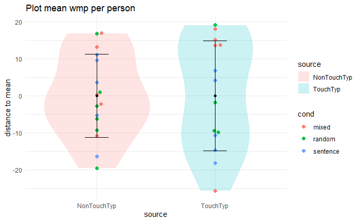

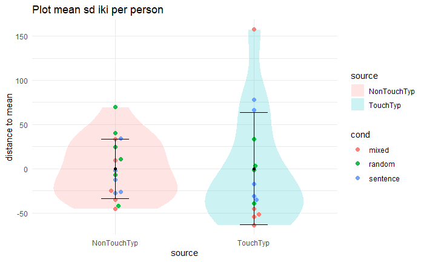

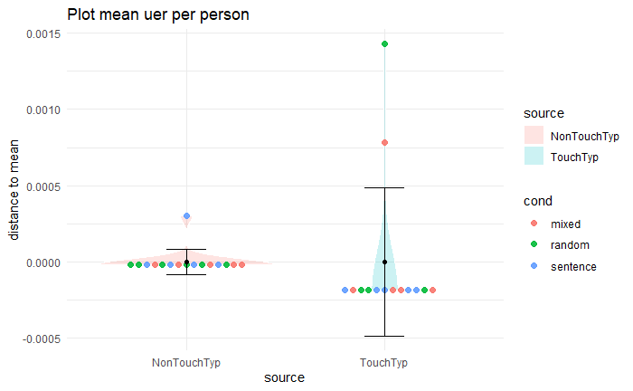

```r
print(m(attributelist, 2))
```

```r
print(m(attributelist, 3))
```

[output not shown]

# Plots of all conditions per group

For each condition a plot comparing touch- and non-touch-typist for all the different metrics.

```r
datalist <- list(sentence_both, mixed_both, random_both)
cond <- list("sentence_both", "mixed_both", "random_both")
i = 1
condition_model <- vector("list", 3)
for (df in datalist){
curr_mod <- paste("model", i, sep="_")
print(i)
condition_model[[curr_mod]] <- lapply(attributelist, function(x){
curr_lm <- lm(substitute(i~ source, list(i = as.name(x))), data=df)


summary(curr_lm)
p <- ggplot(data = df, aes_string(x = "source", y = x)) +
  geom_point(color='blue')+
  ggtitle(as.character(cond[[i]]))

assign(curr_mod,p + stat_summary(fun.data=mean_sdl, fun.args = list(mult=1),
        geom="errorbar", color="red", width=0.2) +
  stat_summary(fun.y=mean, geom="point", color="red"))
})
i = i+1
}
```

```
[1] 1
```

```
`fun.y` is deprecated. Use `fun` instead.`fun.y` is deprecated. Use `fun` instead.`fun.y` is deprecated. Use `fun` instead.`fun.y` is deprecated. Use `fun` instead.
```

```
[1] 2
```

```
`fun.y` is deprecated. Use `fun` instead.`fun.y` is deprecated. Use `fun` instead.`fun.y` is deprecated. Use `fun` instead.`fun.y` is deprecated. Use `fun` instead.
```

```
[1] 3
```

```
`fun.y` is deprecated. Use `fun` instead.`fun.y` is deprecated. Use `fun` instead.`fun.y` is deprecated. Use `fun` instead.`fun.y` is deprecated. Use `fun` instead.
```

```
[[1]]
NULL

[[2]]
NULL

[[3]]
NULL

$model_1
$model_1[[1]]

$model_1[[2]]

$model_1[[3]]

$model_1[[4]]


$model_2
$model_2[[1]]

$model_2[[2]]

$model_2[[3]]

$model_2[[4]]


$model_3
$model_3[[1]]

$model_3[[2]]

$model_3[[3]]

$model_3[[4]]
```

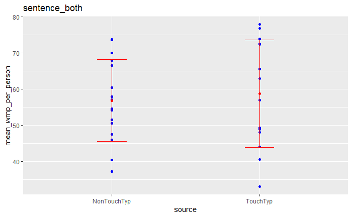

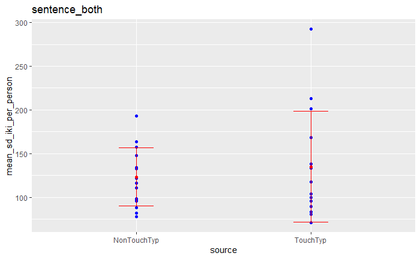

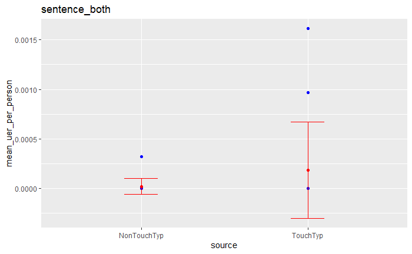

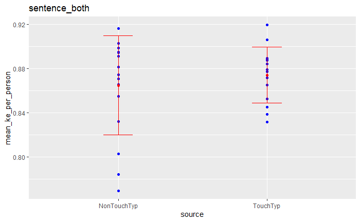

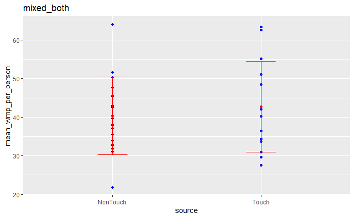

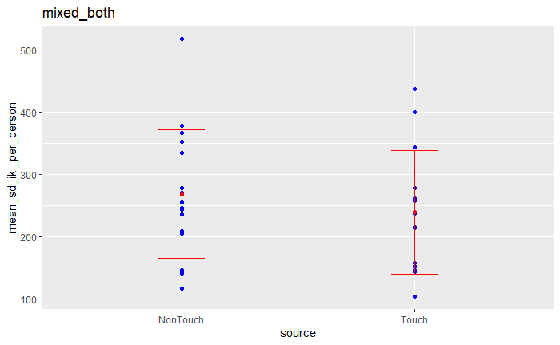

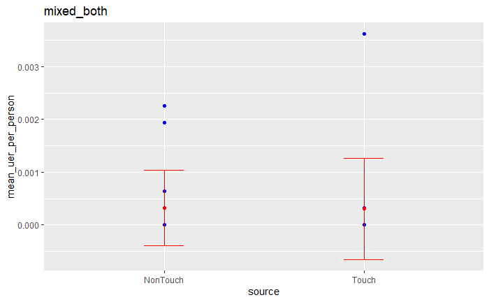

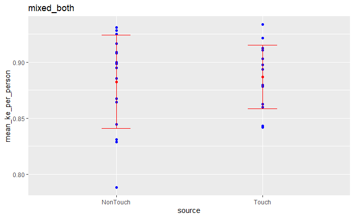

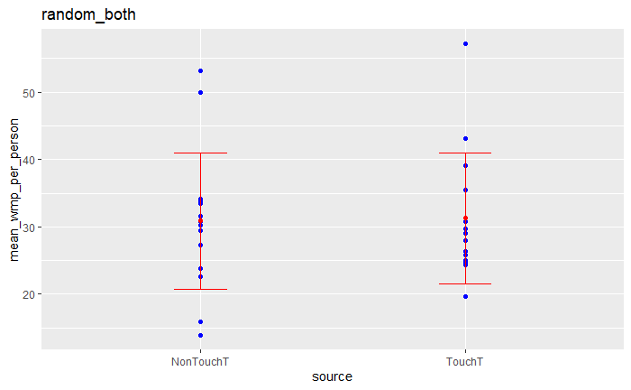

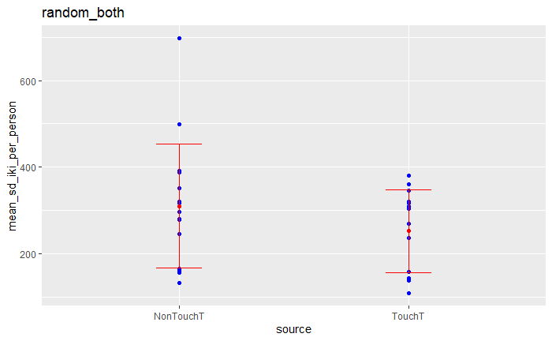

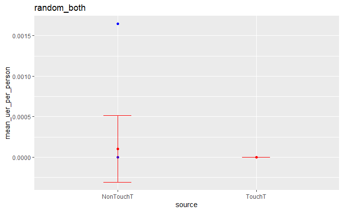

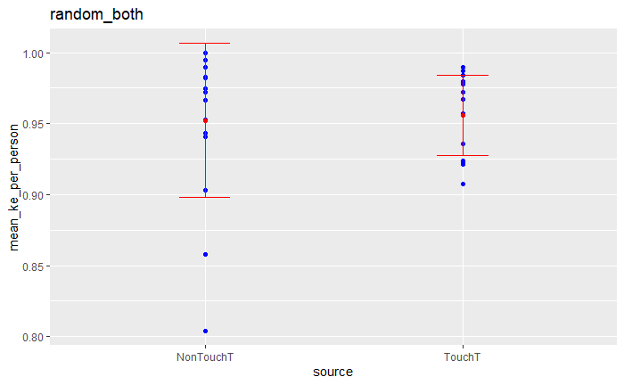

```r
print(condition_model)
```